# Group by Operations

Split - Apply - Combine strategy:

```python
import pandas as pd
import numpy as np
```

First we slice the data by some category, like: for example cities in Real Estate database.

Next we apply basic statstics for eahc variable (city) : mean , medians , average squares etc.

Finally, we are combide, bond the statistics in the single table.

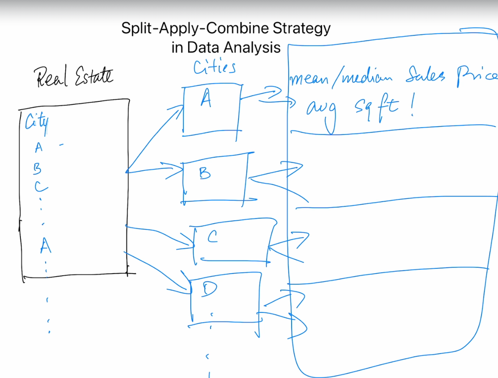

```python
from IPython.display import Image, display
display(Image(filename='./samples_rw/split-combine.png', width=550))
```

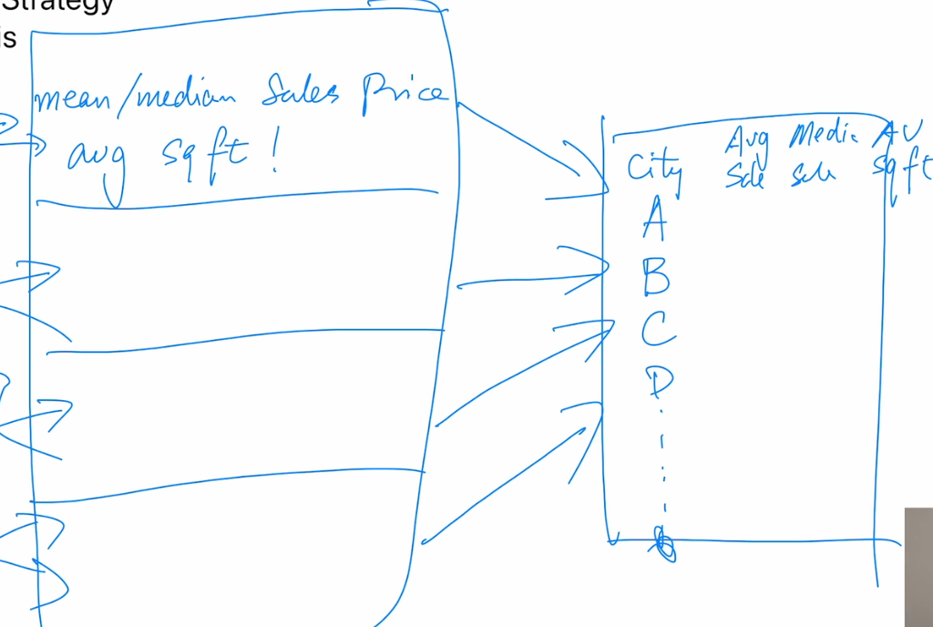

```python
from IPython.display import Image, display
display(Image(filename='./samples_rw/combined.png', width=550))
```

split >> calculate variables / apply analyses >> Combine results in 1 table.

```python
realtor = pd.read_csv('./samples_rw/realtor-data.csv', parse_dates=['prev_sold_date'])
restaurants = pd.read_csv('./samples_rw/california_restaurants.csv')
```

```python
realtor.head(2)
```

|  | status | bed | bath | acre_lot | city | state | zip_code | house_size | prev_sold_date | price |
| --- | --- | --- | --- | --- | --- | --- | --- | --- | --- | --- |
| 0 | for_sale | 3.0 | 2.0 | 0.12 | Adjuntas | Puerto Rico | 601.0 | 920.0 | NaT | 105000.0 |
| 1 | for_sale | 4.0 | 2.0 | 0.08 | Adjuntas | Puerto Rico | 601.0 | 1527.0 | NaT | 80000.0 |

1. Which cities have the most expensive and mortgage expensive home?
2. Which cities have the biggest and smallest homes as measured by square footage in the US California?
3. Which bedroom-bathroom combos are the most common in the Califrnian maerket?

First, group the data and split it:

this is the object created from the groubed cities. I need to put results in the tuples

```python
# to group it with proper table result, use index as false!
grp = realtor.groupby('city', as_index=False)
grp
```

```
<pandas.core.groupby.generic.DataFrameGroupBy object at 0x7bbc5df4d340>
```

# groupby ( )

groupby function:

- Scans the city column
- Finds unique city names
- Creates logical buckets (groups) for each city
- Stores row indexes belonging to each bucket

It is a index grouped, so we need iter to print in the grouped results

| city | price | beds |
| --- | --- | --- |
| London | 500 | 2 |
| London | 650 | 3 |
| Bristol | 420 | 2 |
| Leeds | 380 | 3 |
| Bristol | 460 | 3 |

London → rows [0, 1] Bristol → rows [2, 4] Leeds → row [3]

```python
for city, data in grp:
  print(city) # how many unique cities
  print(data.shape[0]) # how many rows per each unique city
```

```
Abbot
15
Aberdeen
201
Abington
179
Absecon
353
Absecon Highlands
4
Accord
5
Acton
851
Acushnet
97
Acworth
131
Adams
870
Adamstown Township
7
Addisleigh Park
27
Addison
125
Adelphia
3
Adjuntas
33
Agawam
872
Aguada
261
Aguadilla
188
Aguas Buenas
82
Aibonito
102
```

[output cut: 4919 more lines]

```
197
Yarmouth
239
Yarmouth Port
224
Yauco
108
Yeadon
13
Yonkers
1893
York
430
Yulan
6
```

Summarize (aggegate) the data / rows / by groups:

```python
# grp = realtor.groupby('city', as_index=False)
median_price_by_city = grp['price'].median()
median_price_by_city
# also it works realtor.groupby('city' as_index=False)['price'].median()
```

|  | city | price |
| --- | --- | --- |
| 0 | Abbot | 39900.0 |
| 1 | Aberdeen | 499900.0 |
| 2 | Abington | 510000.0 |
| 3 | Absecon | 246400.0 |
| 4 | Absecon Highlands | 89000.0 |
| ... | ... | ... |
| 2482 | Yauco | 70500.0 |
| 2483 | Yeadon | 215000.0 |
| 2484 | Yonkers | 299900.0 |
| 2485 | York | 619000.0 |
| 2486 | Yulan | 188500.0 |

2487 rows × 2 columns

Let's create the same result (aggregated data for grouped rows) for the new created column, which merges city and province together:

```python
realtor['city_state'] = realtor.city + ', ' + realtor.state
grp_realtor = realtor.groupby('city_state', as_index=False)
grp_realtor
```

```
<pandas.core.groupby.generic.DataFrameGroupBy object at 0x7bbc086b4e00>
```

Proper grouping is important. For example there are two Abington cities, one in Massachusetts, and second in Pensylvania states. Finally, 3061 rows (cities) from 2487 cieties in the grp variable, confirms that some cieties names are the same in two or more states.

```python
grp_realtor['price'].median()
```

|  | city_state | price |
| --- | --- | --- |
| 0 | Abbot, Maine | 39900.0 |
| 1 | Aberdeen, New Jersey | 499900.0 |
| 2 | Abington, Massachusetts | 525000.0 |
| 3 | Abington, Pennsylvania | 320000.0 |
| 4 | Absecon Highlands, New Jersey | 89000.0 |
| ... | ... | ... |
| 3056 | Yauco, Puerto Rico | 70500.0 |
| 3057 | Yeadon, Pennsylvania | 215000.0 |
| 3058 | Yonkers, New York | 299900.0 |
| 3059 | York, Maine | 619000.0 |
| 3060 | Yulan, New York | 188500.0 |

3061 rows × 2 columns

## aggregated data by group

If we need more that singlw aggregated result in the table, we are able to use agg( ) function:

```python
cities = grp_realtor['price'].agg(['mean', 'median', 'max', 'min', 'std', 'count', 'nunique'])
cities
```

|  | city_state | mean | median | max | min | std | count | nunique |
| --- | --- | --- | --- | --- | --- | --- | --- | --- |
| 0 | Abbot, Maine | 200013.333333 | 39900.0 | 425000.0 | 21900.0 | 1.922600e+05 | 15 | 4 |
| 1 | Aberdeen, New Jersey | 452762.691542 | 499900.0 | 849900.0 | 49000.0 | 1.613619e+05 | 201 | 41 |
| 2 | Abington, Massachusetts | 821046.385542 | 525000.0 | 7900000.0 | 250000.0 | 1.498363e+06 | 166 | 16 |
| 3 | Abington, Pennsylvania | 306587.692308 | 320000.0 | 399440.0 | 229000.0 | 5.231031e+04 | 13 | 12 |
| 4 | Absecon Highlands, New Jersey | 89000.000000 | 89000.0 | 89000.0 | 89000.0 | 0.000000e+00 | 4 | 1 |
| ... | ... | ... | ... | ... | ... | ... | ... | ... |
| 3056 | Yauco, Puerto Rico | 151775.925926 | 70500.0 | 4000000.0 | 32500.0 | 3.914199e+05 | 108 | 16 |
| 3057 | Yeadon, Pennsylvania | 208861.538462 | 215000.0 | 280000.0 | 25000.0 | 7.927538e+04 | 13 | 8 |
| 3058 | Yonkers, New York | 421251.046487 | 299900.0 | 2199000.0 | 44900.0 | 3.096938e+05 | 1893 | 198 |
| 3059 | York, Maine | 929687.190698 | 619000.0 | 5950000.0 | 21000.0 | 1.222300e+06 | 430 | 43 |
| 3060 | Yulan, New York | 254166.666667 | 188500.0 | 425000.0 | 149000.0 | 1.335008e+05 | 6 | 3 |

3061 rows × 8 columns

Sort created table by the MEDIAN value: in the ascending order.

```python
cities.sort_values('median', ascending=True)
```

|  | city_state | mean | median | max | min | std | count | nunique |
| --- | --- | --- | --- | --- | --- | --- | --- | --- |
| 2130 | Port Murray, New Jersey | 9.700000e+03 | 8000.0 | 15000.0 | 8000.0 | 2.790858e+03 | 10 | 3 |
| 1377 | Laureldale, New Jersey | 3.066923e+04 | 9900.0 | 279900.0 | 9900.0 | 7.488453e+04 | 13 | 2 |
| 1398 | Lehman, Pennsylvania | 1.310909e+04 | 12500.0 | 17500.0 | 9900.0 | 2.700909e+03 | 11 | 4 |
| 1969 | Orient, Maine | 1.250000e+04 | 12500.0 | 12500.0 | 12500.0 | NaN | 1 | 1 |
| 1930 | Oakfield, Maine | 1.931667e+04 | 14000.0 | 30000.0 | 14000.0 | 7.853295e+03 | 12 | 3 |
| ... | ... | ... | ... | ... | ... | ... | ... | ... |
| 2650 | Tisbury, Massachusetts | 6.406333e+06 | 5750000.0 | 11600000.0 | 699000.0 | 4.828756e+06 | 15 | 3 |
| 2424 | Siasconset, Massachusetts | 6.495000e+06 | 6495000.0 | 6495000.0 | 6495000.0 | 0.000000e+00 | 3 | 1 |
| 1628 | Middletown Township, New Jersey | 9.200000e+06 | 9199999.5 | 17500000.0 | 899999.0 | 9.092195e+06 | 6 | 2 |
| 2243 | Rochdale Village, New York | 9.800000e+06 | 9800000.0 | 9800000.0 | 9800000.0 | 0.000000e+00 | 3 | 1 |
| 2821 | Waterfront, Massachusetts | 1.200000e+07 | 12000000.0 | 12000000.0 | 12000000.0 | 0.000000e+00 | 25 | 1 |

3061 rows × 8 columns

always review dataset to understand the data ypu analysing:

```python
cities.city_state.value_counts()
```

```
city_state
Abbot, Maine                     1
Aberdeen, New Jersey             1
Abington, Massachusetts          1
Abington, Pennsylvania           1
Absecon Highlands, New Jersey    1
                                ..
Yauco, Puerto Rico               1
Yeadon, Pennsylvania             1
Yonkers, New York                1
York, Maine                      1
Yulan, New York                  1
Name: count, Length: 3061, dtype: int64
```

In this code we can combine few commands in the single code row: segragate by city_state , basing on price, and next sort the value by condition:

```python
home_size_by_city = (realtor.groupby('city_state', as_index=False)['price']
  .agg(['min', 'max', 'mean', 'std', 'median', 'count'])
  .sort_values('median', ascending=False)
    )
home_size_by_city
```

|  | city_state | min | max | mean | std | median | count |
| --- | --- | --- | --- | --- | --- | --- | --- |
| 2821 | Waterfront, Massachusetts | 12000000.0 | 12000000.0 | 1.200000e+07 | 0.000000e+00 | 12000000.0 | 25 |
| 2243 | Rochdale Village, New York | 9800000.0 | 9800000.0 | 9.800000e+06 | 0.000000e+00 | 9800000.0 | 3 |
| 1628 | Middletown Township, New Jersey | 899999.0 | 17500000.0 | 9.200000e+06 | 9.092195e+06 | 9199999.5 | 6 |
| 2424 | Siasconset, Massachusetts | 6495000.0 | 6495000.0 | 6.495000e+06 | 0.000000e+00 | 6495000.0 | 3 |
| 2650 | Tisbury, Massachusetts | 699000.0 | 11600000.0 | 6.406333e+06 | 4.828756e+06 | 5750000.0 | 15 |
| ... | ... | ... | ... | ... | ... | ... | ... |
| 1930 | Oakfield, Maine | 14000.0 | 30000.0 | 1.931667e+04 | 7.853295e+03 | 14000.0 | 12 |
| 1969 | Orient, Maine | 12500.0 | 12500.0 | 1.250000e+04 | NaN | 12500.0 | 1 |
| 1398 | Lehman, Pennsylvania | 9900.0 | 17500.0 | 1.310909e+04 | 2.700909e+03 | 12500.0 | 11 |
| 1377 | Laureldale, New Jersey | 9900.0 | 279900.0 | 3.066923e+04 | 7.488453e+04 | 9900.0 | 13 |
| 2130 | Port Murray, New Jersey | 8000.0 | 15000.0 | 9.700000e+03 | 2.790858e+03 | 8000.0 | 10 |

3061 rows × 7 columns

```python
realtor.head(2)
```

|  | status | bed | bath | acre_lot | city | state | zip_code | house_size | prev_sold_date | price | city_state |
| --- | --- | --- | --- | --- | --- | --- | --- | --- | --- | --- | --- |
| 0 | for_sale | 3.0 | 2.0 | 0.12 | Adjuntas | Puerto Rico | 601.0 | 920.0 | NaT | 105000.0 | Adjuntas, Puerto Rico |
| 1 | for_sale | 4.0 | 2.0 | 0.08 | Adjuntas | Puerto Rico | 601.0 | 1527.0 | NaT | 80000.0 | Adjuntas, Puerto Rico |

Grouping by two condition : bedrooms and bathrooms

```python
realtor.groupby(['bed','bath'], as_index=False)['city'].count()
```

|  | bed | bath | city |
| --- | --- | --- | --- |
| 0 | 1.0 | 1.0 | 71933 |
| 1 | 1.0 | 2.0 | 9690 |
| 2 | 1.0 | 3.0 | 317 |
| 3 | 1.0 | 4.0 | 36 |
| 4 | 1.0 | 5.0 | 13 |
| ... | ... | ... | ... |
| 258 | 60.0 | 51.0 | 27 |
| 259 | 68.0 | 28.0 | 6 |
| 260 | 86.0 | 56.0 | 21 |
| 261 | 99.0 | 198.0 | 23 |
| 262 | 123.0 | 123.0 | 1 |

263 rows × 3 columns

we can rename the city name to count as it is actually the counted cities in the table:

We count the cities with the properties which includes some numbers of bathrooms and bedrooms.

The most common property (from the research) are with 3 beds and 2 baths.

```python
combo_count = realtor.groupby(['bed','bath'], as_index=False)['city'].count().rename({'city':'count'}, axis=1)
combo_count.sort_values(by='count', ascending=False)
# we selected the most counts from of quantity of the bath and beds form grouped properties by beds and baths
```

|  | bed | bath | count |
| --- | --- | --- | --- |
| 15 | 3.0 | 2.0 | 114283 |
| 8 | 2.0 | 2.0 | 88319 |
| 0 | 1.0 | 1.0 | 71933 |
| 16 | 3.0 | 3.0 | 69601 |
| 7 | 2.0 | 1.0 | 57583 |
| ... | ... | ... | ... |
| 104 | 9.0 | 17.0 | 1 |
| 207 | 20.0 | 6.0 | 1 |
| 199 | 18.0 | 18.0 | 1 |
| 216 | 20.0 | 24.0 | 1 |
| 262 | 123.0 | 123.0 | 1 |

263 rows × 3 columns

we can reset the index to new table:

```python
combo_counts = combo_count.reset_index(drop=False)
combo_count
```

|  | bed | bath | count |
| --- | --- | --- | --- |
| 0 | 1.0 | 1.0 | 71933 |
| 1 | 1.0 | 2.0 | 9690 |
| 2 | 1.0 | 3.0 | 317 |
| 3 | 1.0 | 4.0 | 36 |
| 4 | 1.0 | 5.0 | 13 |
| ... | ... | ... | ... |
| 258 | 60.0 | 51.0 | 27 |
| 259 | 68.0 | 28.0 | 6 |
| 260 | 86.0 | 56.0 | 21 |
| 261 | 99.0 | 198.0 | 23 |
| 262 | 123.0 | 123.0 | 1 |

263 rows × 3 columns

the preffered approach is on one go, when all changes are in the single code tab:

```python
counts = (realtor
          .groupby(['bed', 'bath'], as_index=False)['city']
          .count()
          .rename({'city': 'counts'}, axis=1)
          .sort_values('counts', ascending=False)
          .reset_index(drop=False)
          )
counts
```

|  | index | bed | bath | counts |
| --- | --- | --- | --- | --- |
| 0 | 15 | 3.0 | 2.0 | 114283 |
| 1 | 8 | 2.0 | 2.0 | 88319 |
| 2 | 0 | 1.0 | 1.0 | 71933 |
| 3 | 16 | 3.0 | 3.0 | 69601 |
| 4 | 7 | 2.0 | 1.0 | 57583 |
| ... | ... | ... | ... | ... |
| 258 | 104 | 9.0 | 17.0 | 1 |
| 259 | 207 | 20.0 | 6.0 | 1 |
| 260 | 199 | 18.0 | 18.0 | 1 |
| 261 | 216 | 20.0 | 24.0 | 1 |
| 262 | 262 | 123.0 | 123.0 | 1 |

263 rows × 4 columns

The easiest way is to apply value_counts function from the pandas, directly on the dataframe:

These are value counts for the beds and baths.

```python
realtor[['bed','bath']].value_counts()
```

```
bed    bath
3.0    2.0      114283
2.0    2.0       88319
1.0    1.0       71937
3.0    3.0       69606
2.0    1.0       57585
                 ...
9.0    17.0          1
20.0   6.0           1
18.0   18.0          1
20.0   24.0          1
123.0  123.0         1
Name: count, Length: 263, dtype: int64
```

We investigate in restaurants, which city containts the highly rated restaurants:

```python
restaurants.head(2)
```

|  | Yelp URL | Name | Street Address | Zip Code | City | State | Price Range | Phone | Rating | Number of Reviews | Website | Menu Link | Image 1 | Image 2 | Image 3 | Category 1 | Category 2 | Category 3 |
| --- | --- | --- | --- | --- | --- | --- | --- | --- | --- | --- | --- | --- | --- | --- | --- | --- | --- | --- |
| 0 | https://www.yelp.com/biz/in-s%C4%ABt-coffee-bu... | In-sīt Coffee | 6930 Beach Blvd Ste L301 | 90621.0 | Buena Park | CA | $ | (714) 670-6958 | 4.0 | 583.0 | NaN | NaN | https://s3-media0.fl.yelpcdn.com/bphoto/TgX8pH... | https://s3-media0.fl.yelpcdn.com/bphoto/e9oSgM... | https://s3-media0.fl.yelpcdn.com/bphoto/gJUxfa... | Coffee & Tea | Waffles | Breakfast & Brunch |
| 1 | https://www.yelp.com/biz/tierra-mia-coffee-wes... | Tierra Mia Coffee | 2301 S Azusa Ave | 91792.0 | West Covina | CA | $$ | NaN | 4.0 | 288.0 | www.tierramiacoffee.com | NaN | https://s3-media0.fl.yelpcdn.com/bphoto/qQC8B3... | https://s3-media0.fl.yelpcdn.com/bphoto/QhVb_D... | https://s3-media0.fl.yelpcdn.com/bphoto/7RiGO2... | Coffee & Tea | NaN | NaN |

Let's group the restaurants by cities. We need to say which column we want to base on.

We want to group by City but we need to base - follow the ratings of each restaurant.

Next aggregate of grouped data with the statistics.

Finally, we set condition to this rating. There must be shown only restaurants above 10 counts.

```python
rating_by_city = restaurants.groupby('City')['Rating'].agg(['mean','median', 'std', 'count']).sort_values('mean', ascending=False)
rating_by_city_10 = rating_by_city.loc[rating_by_city['count'] >= 10]
rating_by_city_10
```

| City | mean | median | std | count |
| --- | --- | --- | --- | --- |
| Chino | 4.500000 | 4.50 | 0.361158 | 24 |
| Ontario | 4.500000 | 4.50 | 0.316228 | 11 |
| Walnut | 4.481481 | 4.50 | 0.448962 | 27 |
| Garden Grove | 4.428571 | 4.50 | 0.422577 | 35 |
| Pomona | 4.413793 | 4.50 | 0.464238 | 29 |
| La Mirada | 4.394737 | 4.50 | 0.657836 | 19 |
| Buena Park | 4.375000 | 4.50 | 0.375484 | 44 |
| La Habra | 4.333333 | 4.50 | 0.645497 | 33 |
| West Covina | 4.333333 | 4.50 | 0.331133 | 39 |
| Whittier | 4.314286 | 4.50 | 0.299158 | 35 |
| Diamond Bar | 4.304054 | 4.50 | 0.502170 | 74 |
| Placentia | 4.303571 | 4.50 | 0.458243 | 28 |
| Anaheim | 4.302013 | 4.50 | 0.550856 | 149 |
| Fullerton | 4.262987 | 4.50 | 0.413016 | 154 |
| Covina | 4.238095 | 4.00 | 0.538958 | 21 |
| City of Industry | 4.229167 | 4.50 | 0.441814 | 24 |
| Orange | 4.205882 | 4.50 | 0.490471 | 68 |
| Claremont | 4.204545 | 4.25 | 0.427035 | 22 |
| Rowland Heights | 4.180556 | 4.00 | 0.368720 | 72 |
| Hacienda Heights | 4.176471 | 4.00 | 0.350944 | 17 |
| Yorba Linda | 4.111111 | 4.00 | 0.461803 | 63 |
| Brea | 4.078431 | 4.00 | 0.599116 | 153 |
| Chino Hills | 4.034091 | 4.00 | 0.379684 | 44 |

```python
restaurants.head(2)
```

|  | Yelp URL | Name | Street Address | Zip Code | City | State | Price Range | Phone | Rating | Number of Reviews | Website | Menu Link | Image 1 | Image 2 | Image 3 | Category 1 | Category 2 | Category 3 |
| --- | --- | --- | --- | --- | --- | --- | --- | --- | --- | --- | --- | --- | --- | --- | --- | --- | --- | --- |
| 0 | https://www.yelp.com/biz/in-s%C4%ABt-coffee-bu... | In-sīt Coffee | 6930 Beach Blvd Ste L301 | 90621.0 | Buena Park | CA | $ | (714) 670-6958 | 4.0 | 583.0 | NaN | NaN | https://s3-media0.fl.yelpcdn.com/bphoto/TgX8pH... | https://s3-media0.fl.yelpcdn.com/bphoto/e9oSgM... | https://s3-media0.fl.yelpcdn.com/bphoto/gJUxfa... | Coffee & Tea | Waffles | Breakfast & Brunch |
| 1 | https://www.yelp.com/biz/tierra-mia-coffee-wes... | Tierra Mia Coffee | 2301 S Azusa Ave | 91792.0 | West Covina | CA | $$ | NaN | 4.0 | 288.0 | www.tierramiacoffee.com | NaN | https://s3-media0.fl.yelpcdn.com/bphoto/qQC8B3... | https://s3-media0.fl.yelpcdn.com/bphoto/QhVb_D... | https://s3-media0.fl.yelpcdn.com/bphoto/7RiGO2... | Coffee & Tea | NaN | NaN |

Find the best restaurants in each city by Price Range basing on rating criteria.

Sort the result in the table by mean. Ensure that results are collected above 10 feedback by restaurant.

```python
highly_rated = restaurants.groupby(['City', 'Price Range'])['Rating'].agg(['mean','median', 'std', 'count']).sort_values('mean')
highly_rated = highly_rated.loc[highly_rated['count'] >= 10]
highly_rated
```

| City | Price Range | mean | median | std | count |
| --- | --- | --- | --- | --- | --- |
| Chino Hills | $$ | 3.951613 | 4.00 | 0.394859 | 31 |
| Orange | $ | 4.076923 | 4.00 | 0.571772 | 13 |
| Brea | $$ | 4.089109 | 4.00 | 0.438155 | 101 |
| Claremont | $$ | 4.093750 | 4.00 | 0.417083 | 16 |
| Pomona | $$ | 4.107143 | 4.00 | 0.289467 | 14 |
| Brea | $ | 4.138889 | 4.00 | 0.659892 | 18 |
| Diamond Bar | $$ | 4.147727 | 4.25 | 0.452121 | 44 |
| Yorba Linda | $$ | 4.170455 | 4.00 | 0.443862 | 44 |
| Orange | $$ | 4.202128 | 4.50 | 0.425538 | 47 |
| Covina | $$ | 4.208333 | 4.50 | 0.620056 | 12 |
| Rowland Heights | $$ | 4.230769 | 4.00 | 0.389338 | 52 |
| Garden Grove | $$ | 4.236842 | 4.00 | 0.348346 | 19 |
| Fullerton | $$ | 4.239130 | 4.50 | 0.415425 | 115 |
| West Covina | $$ | 4.240741 | 4.50 | 0.289906 | 27 |
| Anaheim | $$ | 4.275000 | 4.50 | 0.489150 | 100 |
| Whittier | $$ | 4.280000 | 4.50 | 0.291548 | 25 |
| Buena Park | $$ | 4.282609 | 4.50 | 0.331185 | 23 |
| Placentia | $$ | 4.309524 | 4.50 | 0.334522 | 21 |
| City of Industry | $$ | 4.318182 | 4.50 | 0.252262 | 11 |
| Fullerton | $ | 4.354167 | 4.50 | 0.453948 | 24 |
| Chino | $$ | 4.361111 | 4.50 | 0.287257 | 18 |
| La Habra | $$ | 4.386364 | 4.50 | 0.554888 | 22 |
| Anaheim | $ | 4.409091 | 4.50 | 0.590326 | 22 |
| Walnut | $$ | 4.470588 | 4.50 | 0.483173 | 17 |

We check the Price Range by rating scores.

```python
price_range = restaurants.groupby(['Price Range'], as_index=False)['Rating'].agg(['mean','median', 'std', 'count']).sort_values('Price Range',ascending=False)
price_range
```

|  | Price Range | mean | median | std | count |
| --- | --- | --- | --- | --- | --- |
| 3 | $$$$ | 4.428571 | 4.5 | 0.181568 | 14 |
| 2 | $$$ | 4.115385 | 4.0 | 0.637302 | 26 |
| 1 | $$ | 4.215591 | 4.5 | 0.431023 | 821 |
| 0 | $ | 4.271845 | 4.5 | 0.502563 | 206 |

```python
price_range['category'] = ['high rate', 'medium rate', 'standard rate', 'low rate']
price_range.set_index('category')
```

| category | Price Range | mean | median | std | count |
| --- | --- | --- | --- | --- | --- |
| high rate | $$$$ | 4.428571 | 4.5 | 0.181568 | 14 |
| medium rate | $$$ | 4.115385 | 4.0 | 0.637302 | 26 |
| standard rate | $$ | 4.215591 | 4.5 | 0.431023 | 821 |
| low rate | $ | 4.271845 | 4.5 | 0.502563 | 206 |

## transformation by group

This is binary file , faster for reading and saving space.

```python
data = pd.read_parquet('./samples_rw/monthly_stocks.parquet')
data
```

|  | symbol | companyName | date | close |
| --- | --- | --- | --- | --- |
| 0 | A | Agilent Technologies, Inc. | 2017-01-31 | 48.97 |
| 1 | A | Agilent Technologies, Inc. | 2017-02-28 | 51.30 |
| 2 | A | Agilent Technologies, Inc. | 2017-03-31 | 52.87 |
| 3 | A | Agilent Technologies, Inc. | 2017-04-30 | 55.05 |
| 4 | A | Agilent Technologies, Inc. | 2017-05-31 | 60.34 |
| ... | ... | ... | ... | ... |
| 379714 | ZYXI | Zynex, Inc. | 2023-04-30 | 11.44 |
| 379715 | ZYXI | Zynex, Inc. | 2023-05-31 | 9.38 |
| 379716 | ZYXI | Zynex, Inc. | 2023-06-30 | 9.59 |
| 379717 | ZYXI | Zynex, Inc. | 2023-07-31 | 9.76 |
| 379718 | ZYXI | Zynex, Inc. | 2023-08-31 | 7.70 |

379719 rows × 4 columns

Let's check unique syymbols, it means how many unique companies we have

```python
data['symbol'].nunique()
```

```
5772
```

We have 5772 companies listed in the primary stock.

We review the data: non-unique values, size, shape, date format and more.

```python
data.info()
```

```
<class 'pandas.core.frame.DataFrame'>
RangeIndex: 379719 entries, 0 to 379718
Data columns (total 4 columns):
 #   Column       Non-Null Count   Dtype
---  ------       --------------   -----
 0   symbol       379719 non-null  object
 1   companyName  379719 non-null  object
 2   date         379719 non-null  datetime64[us]
 3   close        379719 non-null  float64
dtypes: datetime64[us](1), float64(1), object(2)
memory usage: 11.6+ MB
```

We look at the average of closing prices: by individually or by aggregation.

```python
data['close'].mean()
```

```
np.float64(28521.188146558205)
```

```python
data['close'].agg(['mean', 'max','min', 'std', 'count', 'sum'])
```

```
mean     2.852119e+04
max      3.978000e+09
min      1.000000e-05
std      9.580997e+06
count    3.797190e+05
sum      1.083004e+10
Name: close, dtype: float64
```

To make any sense, we need to split the dataframe by companies (symbols), Next we will process transformation, and compare them back.

Before the transformation, we need to ensure that data is organized in the dataframe correctly, datetime particularly in the correct order.

Even if it looks like sorted, I am sorting it to build the confidence that data are correctly prepared for analyses.

```python
data = data.sort_values(by=['symbol','date'],ascending=True)
data
```

|  | symbol | companyName | date | close |
| --- | --- | --- | --- | --- |
| 0 | A | Agilent Technologies, Inc. | 2017-01-31 | 48.97 |
| 1 | A | Agilent Technologies, Inc. | 2017-02-28 | 51.30 |
| 2 | A | Agilent Technologies, Inc. | 2017-03-31 | 52.87 |
| 3 | A | Agilent Technologies, Inc. | 2017-04-30 | 55.05 |
| 4 | A | Agilent Technologies, Inc. | 2017-05-31 | 60.34 |
| ... | ... | ... | ... | ... |
| 379714 | ZYXI | Zynex, Inc. | 2023-04-30 | 11.44 |
| 379715 | ZYXI | Zynex, Inc. | 2023-05-31 | 9.38 |
| 379716 | ZYXI | Zynex, Inc. | 2023-06-30 | 9.59 |
| 379717 | ZYXI | Zynex, Inc. | 2023-07-31 | 9.76 |
| 379718 | ZYXI | Zynex, Inc. | 2023-08-31 | 7.70 |

379719 rows × 4 columns

Apply the transformation function, percent change.

```python
data.groupby('symbol')['close'].pct_change(1)
```

```
0              NaN
1         0.047580
2         0.030604
3         0.041233
4         0.096094
            ...
379714   -0.046667
379715   -0.180070
379716    0.022388
379717    0.017727
379718   -0.211066
Name: close, Length: 379719, dtype: float64
```

Now, we are ready to create new column with monthly percentage change, where change is noted by each row.

This is a relative change between value and previous value.

**By what value or percentage did this value changed compared to last time?**

```python
data['monthly_return'] = data.groupby('symbol')['close'].pct_change(1)
data
```

|  | symbol | companyName | date | close | monthly_return |
| --- | --- | --- | --- | --- | --- |
| 0 | A | Agilent Technologies, Inc. | 2017-01-31 | 48.97 | NaN |
| 1 | A | Agilent Technologies, Inc. | 2017-02-28 | 51.30 | 0.047580 |
| 2 | A | Agilent Technologies, Inc. | 2017-03-31 | 52.87 | 0.030604 |
| 3 | A | Agilent Technologies, Inc. | 2017-04-30 | 55.05 | 0.041233 |
| 4 | A | Agilent Technologies, Inc. | 2017-05-31 | 60.34 | 0.096094 |
| ... | ... | ... | ... | ... | ... |
| 379714 | ZYXI | Zynex, Inc. | 2023-04-30 | 11.44 | -0.046667 |
| 379715 | ZYXI | Zynex, Inc. | 2023-05-31 | 9.38 | -0.180070 |
| 379716 | ZYXI | Zynex, Inc. | 2023-06-30 | 9.59 | 0.022388 |
| 379717 | ZYXI | Zynex, Inc. | 2023-07-31 | 9.76 | 0.017727 |
| 379718 | ZYXI | Zynex, Inc. | 2023-08-31 | 7.70 | -0.211066 |

379719 rows × 5 columns

To demonstrate this is correct, check that each ever record of any company is NaN.

```python
data.loc[data.symbol == 'AAPL']
```

|  | symbol | companyName | date | close | monthly_return |
| --- | --- | --- | --- | --- | --- |
| 1031 | AAPL | Apple Inc. | 2017-01-31 | 30.3375 | NaN |
| 1032 | AAPL | Apple Inc. | 2017-02-28 | 34.2475 | 0.128883 |
| 1033 | AAPL | Apple Inc. | 2017-03-31 | 35.9150 | 0.048690 |
| 1034 | AAPL | Apple Inc. | 2017-04-30 | 35.9125 | -0.000070 |
| 1035 | AAPL | Apple Inc. | 2017-05-31 | 38.1900 | 0.063418 |
| ... | ... | ... | ... | ... | ... |
| 1106 | AAPL | Apple Inc. | 2023-04-30 | 169.6800 | 0.028987 |
| 1107 | AAPL | Apple Inc. | 2023-05-31 | 177.2500 | 0.044613 |
| 1108 | AAPL | Apple Inc. | 2023-06-30 | 193.9700 | 0.094330 |
| 1109 | AAPL | Apple Inc. | 2023-07-31 | 196.4500 | 0.012785 |
| 1110 | AAPL | Apple Inc. | 2023-08-31 | 187.8700 | -0.043675 |

80 rows × 5 columns

Instead using single transformation method, we can use combo method:

## transform on entire dataframe

I can apply the full list of function in transportation but it cannot be done with groupby method as above.

```python
data['close'].transform(['pct_change', 'cumsum'])
```

|  | pct_change | cumsum |
| --- | --- | --- |
| 0 | NaN | 4.897000e+01 |
| 1 | 0.047580 | 1.002700e+02 |
| 2 | 0.030604 | 1.531400e+02 |
| 3 | 0.041233 | 2.081900e+02 |
| 4 | 0.096094 | 2.685300e+02 |
| ... | ... | ... |
| 379714 | -0.046667 | 1.083004e+10 |
| 379715 | -0.180070 | 1.083004e+10 |
| 379716 | 0.022388 | 1.083004e+10 |
| 379717 | 0.017727 | 1.083004e+10 |
| 379718 | -0.211066 | 1.083004e+10 |

379719 rows × 2 columns

## transform in groupby

It only allows single transformation function in the groupby methods.

```python
data.groupby('symbol')['close'].transform('pct_change')
```

```
0              NaN
1         0.047580
2         0.030604
3         0.041233
4         0.096094
            ...
379714   -0.046667
379715   -0.180070
379716    0.022388
379717    0.017727
379718   -0.211066
Name: close, Length: 379719, dtype: float64
```

```python
data.groupby('symbol')['close'].mean()
```

```
symbol
A       99.336125
AA      35.955625
AACG     1.562500
AADI    27.406233
AAIC     6.417750
          ...
ZVSA     5.719532
ZWS     30.439000
ZYME    19.956404
ZYNE     6.259161
ZYXI     8.101535
Name: close, Length: 5772, dtype: float64
```

We are adding 1 to each records of monthly_return row.

```python
data['temp'] = data['monthly_return'] + 1
data
```

|  | symbol | companyName | date | close | monthly_return | temp |
| --- | --- | --- | --- | --- | --- | --- |
| 0 | A | Agilent Technologies, Inc. | 2017-01-31 | 48.97 | NaN | NaN |
| 1 | A | Agilent Technologies, Inc. | 2017-02-28 | 51.30 | 0.047580 | 1.047580 |
| 2 | A | Agilent Technologies, Inc. | 2017-03-31 | 52.87 | 0.030604 | 1.030604 |
| 3 | A | Agilent Technologies, Inc. | 2017-04-30 | 55.05 | 0.041233 | 1.041233 |
| 4 | A | Agilent Technologies, Inc. | 2017-05-31 | 60.34 | 0.096094 | 1.096094 |
| ... | ... | ... | ... | ... | ... | ... |
| 379714 | ZYXI | Zynex, Inc. | 2023-04-30 | 11.44 | -0.046667 | 0.953333 |
| 379715 | ZYXI | Zynex, Inc. | 2023-05-31 | 9.38 | -0.180070 | 0.819930 |
| 379716 | ZYXI | Zynex, Inc. | 2023-06-30 | 9.59 | 0.022388 | 1.022388 |
| 379717 | ZYXI | Zynex, Inc. | 2023-07-31 | 9.76 | 0.017727 | 1.017727 |
| 379718 | ZYXI | Zynex, Inc. | 2023-08-31 | 7.70 | -0.211066 | 0.788934 |

379719 rows × 6 columns

Now I need to calculate cumulative product by eahc stock , so required grouping the rows.

This must be applied on the TEMP column.

The grouped data by stock cumulates the value in the time. This is the geometrical return, so we are not adding them.

```python
data['cumprod'] = data.groupby('symbol')['temp'].cumprod()
data
```

|  | symbol | companyName | date | close | monthly_return | temp | cumprod |
| --- | --- | --- | --- | --- | --- | --- | --- |
| 0 | A | Agilent Technologies, Inc. | 2017-01-31 | 48.97 | NaN | NaN | NaN |
| 1 | A | Agilent Technologies, Inc. | 2017-02-28 | 51.30 | 0.047580 | 1.047580 | 1.047580 |
| 2 | A | Agilent Technologies, Inc. | 2017-03-31 | 52.87 | 0.030604 | 1.030604 | 1.079641 |
| 3 | A | Agilent Technologies, Inc. | 2017-04-30 | 55.05 | 0.041233 | 1.041233 | 1.124158 |
| 4 | A | Agilent Technologies, Inc. | 2017-05-31 | 60.34 | 0.096094 | 1.096094 | 1.232183 |
| ... | ... | ... | ... | ... | ... | ... | ... |
| 379714 | ZYXI | Zynex, Inc. | 2023-04-30 | 11.44 | -0.046667 | 0.953333 | 42.032027 |
| 379715 | ZYXI | Zynex, Inc. | 2023-05-31 | 9.38 | -0.180070 | 0.819930 | 34.463323 |
| 379716 | ZYXI | Zynex, Inc. | 2023-06-30 | 9.59 | 0.022388 | 1.022388 | 35.234890 |
| 379717 | ZYXI | Zynex, Inc. | 2023-07-31 | 9.76 | 0.017727 | 1.017727 | 35.859492 |
| 379718 | ZYXI | Zynex, Inc. | 2023-08-31 | 7.70 | -0.211066 | 0.788934 | 28.290788 |

379719 rows × 7 columns

Finally, we can state the cumulative return in the table as new column. Again, this is gained value in the time.

```python
data['cumulative_return'] = data['cumprod'] - 1
data
```

|  | symbol | companyName | date | close | monthly_return | temp | cumprod | cumulative_return |
| --- | --- | --- | --- | --- | --- | --- | --- | --- |
| 0 | A | Agilent Technologies, Inc. | 2017-01-31 | 48.97 | NaN | NaN | NaN | NaN |
| 1 | A | Agilent Technologies, Inc. | 2017-02-28 | 51.30 | 0.047580 | 1.047580 | 1.047580 | 0.047580 |
| 2 | A | Agilent Technologies, Inc. | 2017-03-31 | 52.87 | 0.030604 | 1.030604 | 1.079641 | 0.079641 |
| 3 | A | Agilent Technologies, Inc. | 2017-04-30 | 55.05 | 0.041233 | 1.041233 | 1.124158 | 0.124158 |
| 4 | A | Agilent Technologies, Inc. | 2017-05-31 | 60.34 | 0.096094 | 1.096094 | 1.232183 | 0.232183 |
| ... | ... | ... | ... | ... | ... | ... | ... | ... |
| 379714 | ZYXI | Zynex, Inc. | 2023-04-30 | 11.44 | -0.046667 | 0.953333 | 42.032027 | 41.032027 |
| 379715 | ZYXI | Zynex, Inc. | 2023-05-31 | 9.38 | -0.180070 | 0.819930 | 34.463323 | 33.463323 |
| 379716 | ZYXI | Zynex, Inc. | 2023-06-30 | 9.59 | 0.022388 | 1.022388 | 35.234890 | 34.234890 |
| 379717 | ZYXI | Zynex, Inc. | 2023-07-31 | 9.76 | 0.017727 | 1.017727 | 35.859492 | 34.859492 |
| 379718 | ZYXI | Zynex, Inc. | 2023-08-31 | 7.70 | -0.211066 | 0.788934 | 28.290788 | 27.290788 |

379719 rows × 8 columns

We can brush up the columns, so we could remove not required like temp and cumprod:

```python
del data['temp'], data['cumprod']
data
```

|  | symbol | companyName | date | close | monthly_return | cumulative_return |
| --- | --- | --- | --- | --- | --- | --- |
| 0 | A | Agilent Technologies, Inc. | 2017-01-31 | 48.97 | NaN | NaN |
| 1 | A | Agilent Technologies, Inc. | 2017-02-28 | 51.30 | 0.047580 | 0.047580 |
| 2 | A | Agilent Technologies, Inc. | 2017-03-31 | 52.87 | 0.030604 | 0.079641 |
| 3 | A | Agilent Technologies, Inc. | 2017-04-30 | 55.05 | 0.041233 | 0.124158 |
| 4 | A | Agilent Technologies, Inc. | 2017-05-31 | 60.34 | 0.096094 | 0.232183 |
| ... | ... | ... | ... | ... | ... | ... |
| 379714 | ZYXI | Zynex, Inc. | 2023-04-30 | 11.44 | -0.046667 | 41.032027 |
| 379715 | ZYXI | Zynex, Inc. | 2023-05-31 | 9.38 | -0.180070 | 33.463323 |
| 379716 | ZYXI | Zynex, Inc. | 2023-06-30 | 9.59 | 0.022388 | 34.234890 |
| 379717 | ZYXI | Zynex, Inc. | 2023-07-31 | 9.76 | 0.017727 | 34.859492 |
| 379718 | ZYXI | Zynex, Inc. | 2023-08-31 | 7.70 | -0.211066 | 27.290788 |

379719 rows × 6 columns

Check our data of cumulative returm on single stock:

```python
data[data.symbol == 'AAPL']
```

|  | symbol | companyName | date | close | monthly_return | cumulative_return |
| --- | --- | --- | --- | --- | --- | --- |
| 1031 | AAPL | Apple Inc. | 2017-01-31 | 30.3375 | NaN | NaN |
| 1032 | AAPL | Apple Inc. | 2017-02-28 | 34.2475 | 0.128883 | 0.128883 |
| 1033 | AAPL | Apple Inc. | 2017-03-31 | 35.9150 | 0.048690 | 0.183848 |
| 1034 | AAPL | Apple Inc. | 2017-04-30 | 35.9125 | -0.000070 | 0.183766 |
| 1035 | AAPL | Apple Inc. | 2017-05-31 | 38.1900 | 0.063418 | 0.258838 |
| ... | ... | ... | ... | ... | ... | ... |
| 1106 | AAPL | Apple Inc. | 2023-04-30 | 169.6800 | 0.028987 | 4.593078 |
| 1107 | AAPL | Apple Inc. | 2023-05-31 | 177.2500 | 0.044613 | 4.842604 |
| 1108 | AAPL | Apple Inc. | 2023-06-30 | 193.9700 | 0.094330 | 5.393737 |
| 1109 | AAPL | Apple Inc. | 2023-07-31 | 196.4500 | 0.012785 | 5.475484 |
| 1110 | AAPL | Apple Inc. | 2023-08-31 | 187.8700 | -0.043675 | 5.192666 |

80 rows × 6 columns

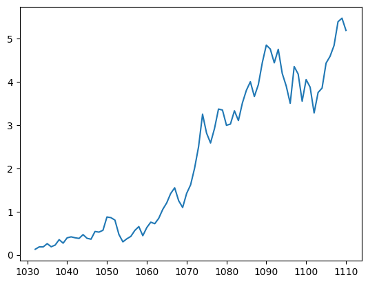

```python
data[data.symbol == 'AAPL']['cumulative_return'].plot()
```